# Trimming with Trimmomatic

Last modified: 08 Mar 2021

# Introduction

This document gives a very biref introduction to read trimming. Read trimming may desirable to remove adapter sequence or poor quality sequence from reads prior to analysis.

Whilst most aligners and the kmer quantification methods can copy with adapter contamination without trimming the reads. It can also be helpful to trim reads in order to get a better idea of the quality of the remaining sequence.

There are a number of tools that can be used for read trimming e.g.:

- [Cutadapt](https://cutadapt.readthedocs.io/en/stable/)
- [Trimmomatic](http://www.usadellab.org/cms/?page=trimmomatic)
- fastp

In this example we will be using Trimmomatic (Bolger, Lohse, and Usadel 2014).

## Fastq with adapter contamination

We have provided a toy data set which features adapter contamination: `fastq/Test_adapter_contamination.fq.gz`.

First run fastqc on the sample:

```bash
mkdir QC
fastqc -o QC fastq/Test_adapter_contamination.fq.gz
```

If you open the resulting FASTQC report you should see that a number of the plots show problems with the data. In particular the “Per sequence GC content” plot and the “Adapter Content” plot:

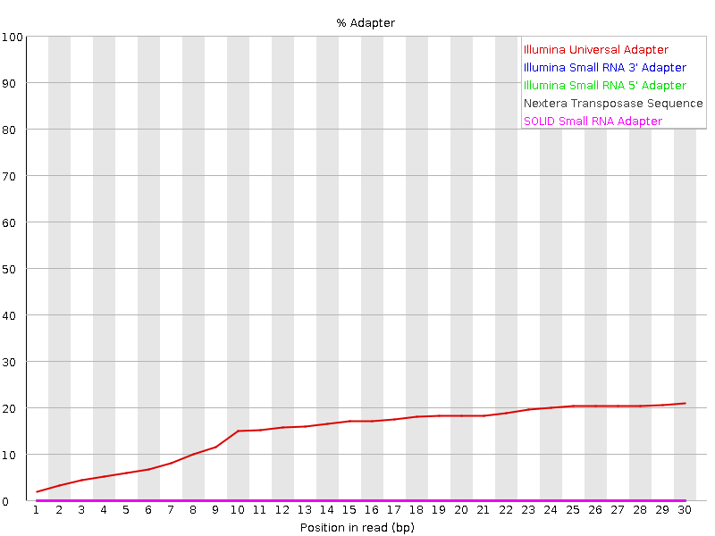

This shows that there is significant contaiminaion with “Illumina Universal Adapter.”

## Trimming with the Trimmomatic tool

To trim the adapter we need to provide Trimmomatic with a fasta file containing the adapters we want to remove. For common Illumina adapters, these are provided in the Trimmomatic directory under `adapters`. Here we have single end data, so we will use the fasta `Trimmomatic-0.39/adapters/TruSeq3-SE.fa`.

Details of all the parameters can be found in the documentation on the Trimmomatic website.

The command we need use is:

```bash
java -jar trimmomatic/trimmomatic-0.39.jar \
    SE \
    -phred33 \
    -trimlog fastq/trimlog.txt \
    fastq/Test_adapter_contamination.fq.gz \
    fastq/Test_adapter_contamination.trimmed.fastq \
    ILLUMINACLIP:trimmomatic/adapters/TruSeq3-SE.fa:2:30:7 \
    MINLEN:15
```

You should see the following message:

```
TrimmomaticSE: Started with arguments:
 -phred33 -trimlog fastq/trimlog.txt fastq/Test_adapter_contamination.fq.gz fastq/Test_adapter_contamination.trimmed.fastq ILLUMINACLIP:trimmomatic/adapters/TruSeq3-SE.fa:2:30:7 MINLEN:15
Automatically using 4 threads
Using Long Clipping Sequence: 'AGATCGGAAGAGCGTCGTGTAGGGAAAGAGTGTA'
Using Long Clipping Sequence: 'AGATCGGAAGAGCACACGTCTGAACTCCAGTCAC'
ILLUMINACLIP: Using 0 prefix pairs, 2 forward/reverse sequences, 0 forward only sequences, 0 reverse only sequences

Input Reads: 31469 Surviving: 26069 (82.84%) Dropped: 5400 (17.16%)
TrimmomaticSE: Completed successfully
```

Trimmomatic has run sucessfully. ~17% of reads have been discarded as they after trimming they are < 15 nucleotides in length.

The file `fastq/trimlog.txt` contains a log of what has happened to each and every read. It contains 5 columns:

1. the read name
2. the surviving sequence length
3. the location of the first surviving base, aka. the amount trimmed from the start
4. the location of the last surviving base in the original read
5. the amount trimmed from the end

For full size fastq files, these log files will be very large. We recommend that if you wish to keep them, you should compress them with `zip` or `gzip`.

Also, note that the output fastq files that Trimmomatic outputs also need be compressed to save disk space.

## Fastq after trimming

Run FASTQC on the new trimmed reads.

```bash
fastqc -o QC fastq/Test_adapter_contamination.trimmed.fastq
```

You should now see that the Illumina Universal Adapter has been removed:

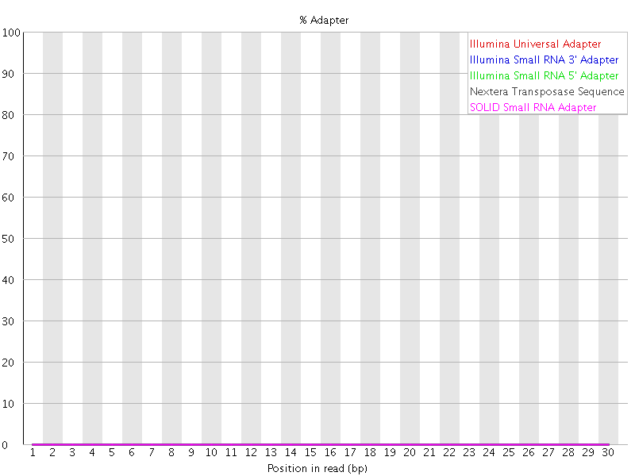

If you look at the “Overrepresented sequences” table. You may observe that there are other contaminants that remain. You may with to modify the adapter fasta file to include these so that they are also removed.

# References

Bolger, Anthony M., Marc Lohse, and Bjoern Usadel. 2014. “Trimmomatic: a flexible trimmer for Illumina sequence data.” *Bioinformatics* 30 (15): 2114–20. https://doi.org/10.1093/bioinformatics/btu170.